# American Time Use Survey 2014 Data

STAT 230

2/7/2017

## The Data

The dataset consists of a survey of individuals about how they spent their time on a particular **diary day**. The survey is conducted as a follow-up to the Current Population Survey, a monthly survey of households conducted by the Bureau of Labor Statistics to examine various characteristics of the U.S. labor force. A select subset of households that have completed the CPS are chosen for ATUS, and one person aged 15+ is randomly chosen from the selected households to respond to the ATUS survey. The data are collected/compiled once a year by the BLS and are publicly available online.

> https://www.bls.gov/tus/datafiles_2014.htm

We’ll work with 3 different components of the survey data files.

```r
load("atusresp.rda")
load("atussum.rda")
load("atuscps.rda")
```

Note that these are not .csv files that we’re loading in. These are more compressed files (in binary format) in a format that is exclusive to R.

The first two relate to (n=11,592) individuals surveyed in ATUS, and the third file is CPS data for the entire year.

Each household is identified by a variable called `tucaseid`:

```r
atusresp$tucaseid[1:5]
```

```
## [1] 2.01401e+13 2.01401e+13 2.01401e+13 2.01401e+13 2.01401e+13
```

Are these all the same individual? It appears that the scientific notation may be obscuring some of the distinguishing digits:

```r
as.character(atusresp$tucaseid[1:5])
```

```
## [1] "20140101140007" "20140101140011" "20140101140028" "20140101140063"
## [5] "20140101140168"
```

What variables are included?

```r
names(atusresp)
```

```
##  [1] "tucaseid"           "earn_week_overtime" "hrs_weekly"
##  [4] "hourly_status"      "other_payment"      "weeks_year"
##  [7] "hrs_weekly2"        "hrs_weekly_other"   "industry_code"
## [10] "occup_code"         "student_status"     "student_level"
## [13] "num_children"       "hourly_wage"        "weekly_earn"
## [16] "holiday"            "diary_date"         "diary_day"
## [19] "wt"
```

This first data frame is the **respondent** data, where we have some variables of interest regarding the respondent’s work-related characteristics as well as the diary day. (I’ve commented this out below so that we don’t end up with a full page of print-out when knitting the file!)

```r
# names(atussum)
```

The second data frame corresponds to the **activity summary** data, where a number of columns like `txxyyzz` summarize the amount of time the individual spent on specific types of activities over the course of the diary day.

## Time Spent Socializing (and Relaxing/Leisure)

Suppose we’d like to study the how much time each individual spends on socializing, relaxing, and leisure. This corresponds to Tier 12. That means that any columns beginning with “t12” in the `atussum` data frame records a different form of socializing, relaxing, and leisure. Henceforth, we’ll just call this class of activities “socializing”.

```r
social_cols <- names(atussum)
social_cols <- grep("t12", social_cols)
social_times <- rowSums(atussum[,social_cols])
```

What we’ve done is created a new variable that contains the total amount of time spent on any form of socializing for each respondent.

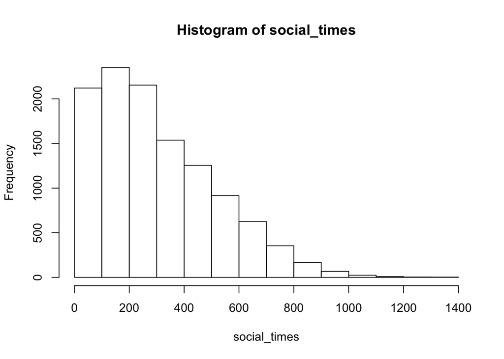

```r
hist(social_times)
```

Now we’d probably like to try to understand how socializing behavior differs among different individuals in the population (different genders, different income levels, etc.). For that, we’ll create a new data frame to hold this newly-created variable, and any other bits of interesting information.

```r
x <- atussum[,c(1, 3:8)] # we like these columns!
x$social_time <- social_times
# head(x)
```

We started with the activity summary dataset and carved out the columns we like. We can also merge in variables in other datasets we might be interested in.

For example, I think the respondents dataset has the following interesting things I might care about (in relation to socializing times).

```r
# names(atusresp)
# head(atusresp)
keep <- c("tucaseid", "num_children", "weekly_earn", "diary_date")
y <- atusresp[, keep]
```

Now we’re ready to do a merge:

```r
x <- merge(x, y, by="tucaseid", all.x = TRUE)
# head(x)
```

The CPS data frame also might have some interesting bits of household information.

```r
keep <- c("tucaseid", "age", "famincome", "hh_size", "atus") # use age to check
y <- atuscps[,keep]
z <- merge(x, y,by="tucaseid", all.x=TRUE)
```

Hmm, something looks a bit weird. Row 2 of the dataset actually has `atus=0`, suggesting this person was not surveyed in the ATUS and `age.x` differs from `age.y`. What’s going on here?

```r
head(z)
```

```
##      tucaseid age.x sex                      edu       race hispanic metro
## 1 2.01401e+13    20   F   2. high school diploma White only      Yes   Yes
## 2 2.01401e+13    16   F 1. < high school diploma Black only       No   Yes
## 3 2.01401e+13    16   F 1. < high school diploma Black only       No   Yes
## 4 2.01401e+13    65   F 1. < high school diploma White only      Yes   Yes
## 5 2.01401e+13    65   F 1. < high school diploma White only      Yes   Yes
## 6 2.01401e+13    65   F 1. < high school diploma White only      Yes   Yes
##   social_time num_children weekly_earn diary_date age.y
## 1          30            1          NA   20140126    20
## 2         200            1     1846.15   20140130    33
## 3         200            1     1846.15   20140130    16
## 4         255            3          NA   20140127    35
## 5         255            3          NA   20140127    65
## 6         255            3          NA   20140127    38
##                famincome hh_size atus
## 1            1. < $5,000       1    1
## 2 11. $40,000 to $49,999       2    0
## 3 11. $40,000 to $49,999       2    1
## 4 10. $35,000 to $39,999       6    0
## 5 10. $35,000 to $39,999       6    1
## 6 10. $35,000 to $39,999       6    0
```

Turns out we need to merge in not only by ‘tucaseid’, but also by ‘atus == 1’.

```r
keep <- c("tucaseid", "age", "sex", "famincome", "hh_size") # use age to check
y <- atuscps[atuscps$atus == 1,keep]
z <- merge(x, y,by="tucaseid", all.x=TRUE)
head(z)
```

```
##      tucaseid age.x sex.x                      edu       race hispanic
## 1 2.01401e+13    20     F   2. high school diploma White only      Yes
## 2 2.01401e+13    16     F 1. < high school diploma Black only       No
## 3 2.01401e+13    65     F 1. < high school diploma White only      Yes
## 4 2.01401e+13    50     F   2. high school diploma Black only       No
## 5 2.01401e+13    23     F   2. high school diploma Black only       No
## 6 2.01401e+13    85     M 1. < high school diploma Black only       No
##   metro social_time num_children weekly_earn diary_date age.y sex.y
## 1   Yes          30            1          NA   20140126    20     F
## 2   Yes         200            1     1846.15   20140130    16     F
## 3   Yes         255            3          NA   20140127    65     F
## 4    No         460            0          NA   20140126    50     F
## 5    No         120            1          NA   20140129    23     F
## 6   Yes        1140            0          NA   20140126    85     M
##                famincome hh_size
## 1            1. < $5,000       1
## 2 11. $40,000 to $49,999       2
## 3 10. $35,000 to $39,999       6
## 4            1. < $5,000       1
## 5    3. $7,500 to $9,999       2
## 6 13. $60,000 to $74,999       2
```

Let’s take a look at possible discrepancies in the two age variables:

```r
table(abs(z$age.x-z$age.y))
```

```
##
##    0    1    2    3    4    5    6    7    8    9   10   11   12   13   14
## 9436 1962   29   13   14    8    9    5    6   10   12    6    5    4    4
##   15   16   17   18   19   20   21   22   24   26   27   28   29   30   31
##    4    7    2    4    1    1    5    3    4    2    3    4    3    6    3
##   32   33   36   37   38   39   40   44   48   49   57   64
##    1    3    1    1    1    3    1    2    1    1    1    1
```

```r
w <- which(abs(z$age.x-z$age.y) > 3)
```

According to the FAQ’s below, there is a gap between the time when the individuals were interviewed for CPS and when they’re interviewed for ATUS:

> https://www.bls.gov/tus/atusfaqs.htm#4

Maybe this can help describe discrepancies of 1 year or less. The stranger discrepancies are larger than 1 year.

Now peeking at the first few that have a gap of more than 3 years:

```r
head(z[w,])
```

```
##         tucaseid age.x sex.x                    edu       race hispanic
## 106 2.014010e+13    59     F    4. associate degree White only       No
## 127 2.014011e+13    55     F    4. associate degree White only       No
## 128 2.014011e+13    80     F 2. high school diploma White only       No
## 140 2.014011e+13    25     M        3. some college Black only       No
## 278 2.014011e+13    85     M        3. some college White only       No
## 318 2.014011e+13    66     F     6. master's degree Black only       No
##     metro social_time num_children weekly_earn diary_date age.y sex.y
## 106   Yes         255            0      800.00   20140127    67     F
## 127   Yes          90            0      769.23   20140114    29     F
## 128   Yes         120            0          NA   20140106    23     F
## 140   Yes         120            0     1015.00   20140112    37     M
## 278   Yes         180            0     2019.23   20140109    36     M
## 318   Yes         300            0          NA   20140101    62     F
##                    famincome hh_size
## 106   14. $75,000 to $99,999       2
## 127   14. $75,000 to $99,999       2
## 128              1. < $5,000       1
## 140   11. $40,000 to $49,999       2
## 278 15. $100,000 to $149,999       2
## 318   13. $60,000 to $74,999       1
```

Who is this first person and what do we know about their household? Could there have been a mix-up with the ‘atus’ variable? Maybe the spouse was interviewed for ATUS instead?

```r
first_person <-  z$tucaseid[w[1]]
atuscps[atuscps$tucaseid == first_person,]
```

```
##        tucaseid lineid    region      division              famincome
## 316 2.01401e+13      1 Northeast Mid. Atlantic 14. $75,000 to $99,999
## 317 2.01401e+13      2 Northeast Mid. Atlantic 14. $75,000 to $99,999
##                  housing_type month hh_size                  edu sex
## 316 1. House, apartment, flat    11       2  4. associate degree   F
## 317 1. House, apartment, flat    11       2 5. bachelor's degree   M
##                     citizen age atus
## 316 1. Native, born in U.S.  67    1
## 317 1. Native, born in U.S.  57    0
```

Doesn’t seem likely to be the case. Maybe we should give up on cleaning the data for these individuals with more than 1 year in discrepancy. After all there aren’t that many of them:

```r
sum(abs(z$age.x-z$age.y) > 1)
```

```
## [1] 194
```

```r
z <- z[abs(z$age.x-z$age.y) <= 1,]
```